# FinalProject

In our project, we are comparing the relative stats and draft order of players in a certain positional side (Offense vs Defense) and how it relates to the money they make in their first contract. For each side of the ball we have at 2 statistics (draft order and average salary) that we will compare against first contract earned to see if there is any relation between draft order or performance that relates to earning a contract. In total, we have 6 positional groups (3 on each side of the ball) to analyze, and we have pulled data from draft years 2010 to 2013. In our final write-up we will go more in depth by position and analyze their skill statistics versus their average salaries after their rookie year.

```r
setwd("~/Spring/Stat/Final")
QB_Data <- read.csv("QB_Data.csv")
RB_Data <- read.csv("RB_Data.csv")
WR_Data <- read.csv("WR_Data.csv")
DL_Data <- read.csv("DL_Data.csv")
LB_Data <- read.csv("LB_Data.csv")
DB_Data <- read.csv("DB_Data.csv")
Offense <- read.csv("Offense.csv")
# Defense <- read.csv("Defense.csv")
```

```r
Mode <- function(x) {
  ux <- unique(x)
  ux[which.max(tabulate(match(x, ux)))]
}

FindOutliers <- function(x) {
  lowerq = quantile(x)[2]
  upperq = quantile(x)[4]
  iqr = upperq - lowerq
  extreme.threshold.upper = (iqr * 3) + upperq
  extreme.threshold.lower = lowerq - (iqr * 3)
  result <- which(x > extreme.threshold.upper | x < extreme.threshold.lower)
}
```

The first positional side we are discussing will be the Offensive side (3 positions - QB, RB, and WR)

```r
OffenseDraftOrders <- Offense$Draft.Order
OffenseSalary <- Offense$Avg.Salary..million.
```

The measures of central tendencies of Offensive salaries are as follows (in the order: Mean, Median, Mode)

```r
AvgOffenseSalary <- mean(OffenseSalary)
MedianOffenseSalary <- median(OffenseSalary)
ModeOffenseSalary <- Mode(OffenseSalary)
AvgOffenseSalary
```

```
## [1] 6.045944
```

```r
MedianOffenseSalary
```

```
## [1] 1.8935
```

```r
ModeOffenseSalary
```

```
## [1] 8
```

```r
RangeOffenseSalary <- range(OffenseSalary)
VarianceOffenseSalary <- var(OffenseSalary)
StdOffenseSalary <- sqrt(VarianceOffenseSalary)
RangeOffenseSalary
```

```
## [1]  0.116 28.000
```

```r
VarianceOffenseSalary
```

```
## [1] 58.10113
```

```r
StdOffenseSalary
```

```
## [1] 7.62241
```

The Correlation test between Offensive Draft Position and Offensive Salary is as follows:

```r
cor.test(OffenseDraftOrders, OffenseSalary)
```

```
##
##  Pearson's product-moment correlation
##
## data:  OffenseDraftOrders and OffenseSalary
## t = -0.29752, df = 16, p-value = 0.7699
## alternative hypothesis: true correlation is not equal to 0
## 95 percent confidence interval:
##  -0.5229353  0.4067825
## sample estimates:
##         cor
## -0.07417432
```

The linear regression between Offensive Draft Position and Offensive Salary is as follows:

```r
lm(OffenseSalary ~ OffenseDraftOrders)
```

```
##
## Call:
## lm(formula = OffenseSalary ~ OffenseDraftOrders)
##
## Coefficients:
##        (Intercept)  OffenseDraftOrders
##            6.68330            -0.01055
```

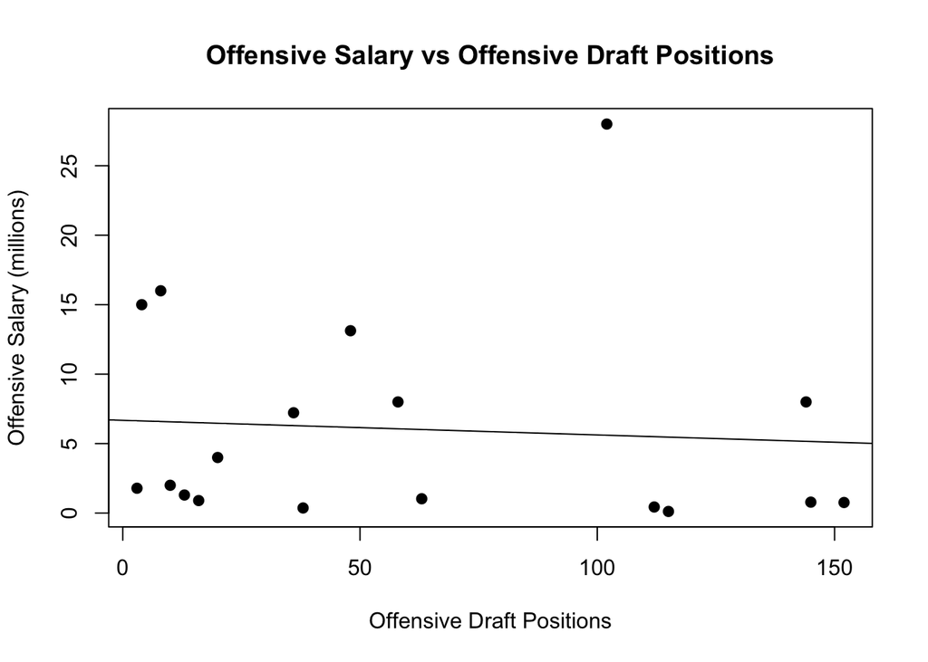

```r
plot(OffenseDraftOrders, OffenseSalary, main="Offensive Salary vs Offensive Draft Positions",
   xlab="Offensive Draft Positions", ylab="Offensive Salary (millions)", pch=19)
abline(lm(OffenseSalary ~ OffenseDraftOrders))
```

Below is a normality plot for Offensive Salary to determine if the sample is drawn from a normal distribution

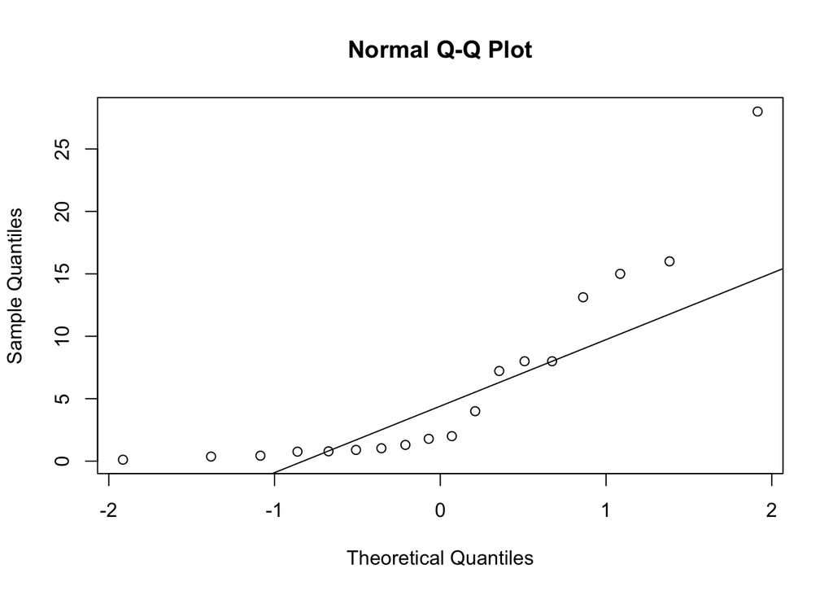

```r
qqnorm(OffenseSalary)
qqline(OffenseSalary)
```

Outlier Check (The outliers of the Offense Salaries are listed below)

```r
OffenseOutliers <- FindOutliers(OffenseSalary)
OffenseOutliers
```

```
## integer(0)
```

As you can see there are no outliers